# Lineas de tendencia

Grandez

26/5/2021

## Introducción

Dado un conjunto de cotizaciones, tipícamente se acostumbra a trazar una linea que o bien una máximos o mínimos locales para identificar las resistencias y los soportes, o bien modele las cotizaciones en si mediante algún modelo de regresión linear.

Con el angulo de la recta respecto al eje de abcisas nos da cierta información acerca de la tendencia y fuerza de ese valor bursatil

Veamos estos dos ejemplos

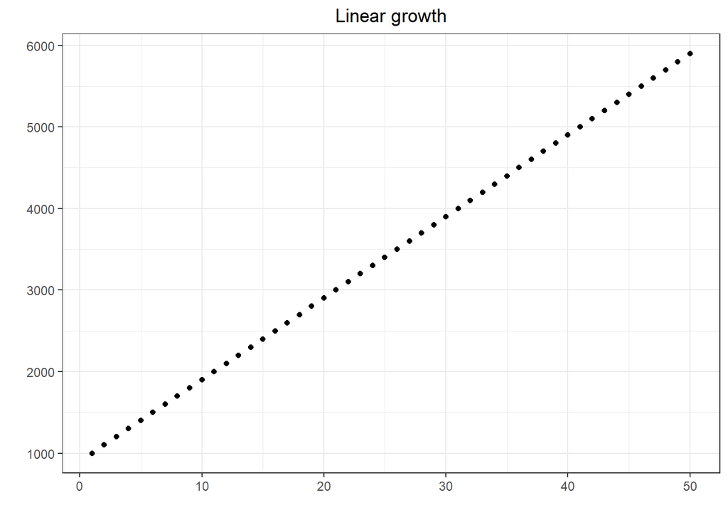

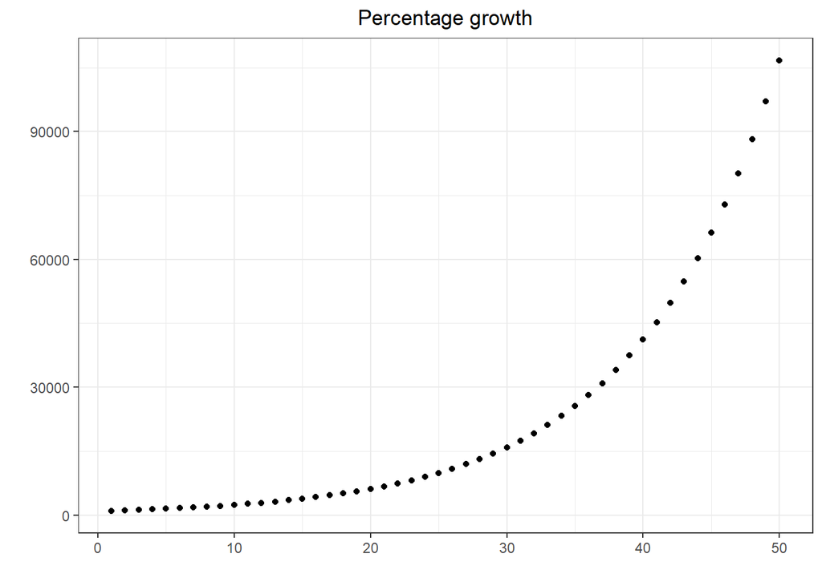

**¿Cual de las dos opciones es mejor?**

### Escalas y tamaños

El primer error a la hora de comparar estos gráficos, son las escalas utilizadas y los tamaños de los gráficos, la escala influye por que si no son equivalentes **no son comparables**.

Veamos que ocurre si los unificamos integrando las dos series en el mismo gráfico:

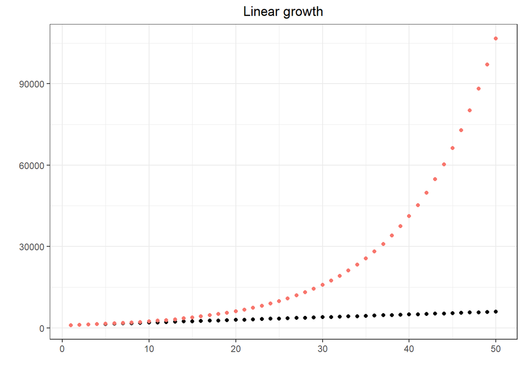

**El problema del tamaño de los gráficos es que produce distorsión en la relación entre los ejes**

### Lineas de tendencia

Agreguemos ahora las lineas que nos indican la tendencia, expresados como la ecuación de la recta: $y = \alpha + \beta x$ donde $\beta$ se suele conocer como *pendiente* de la recta

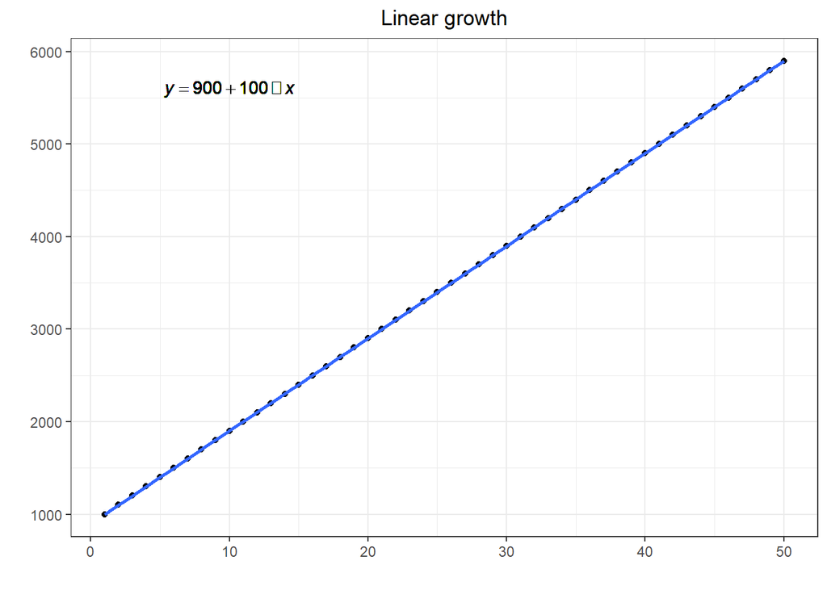

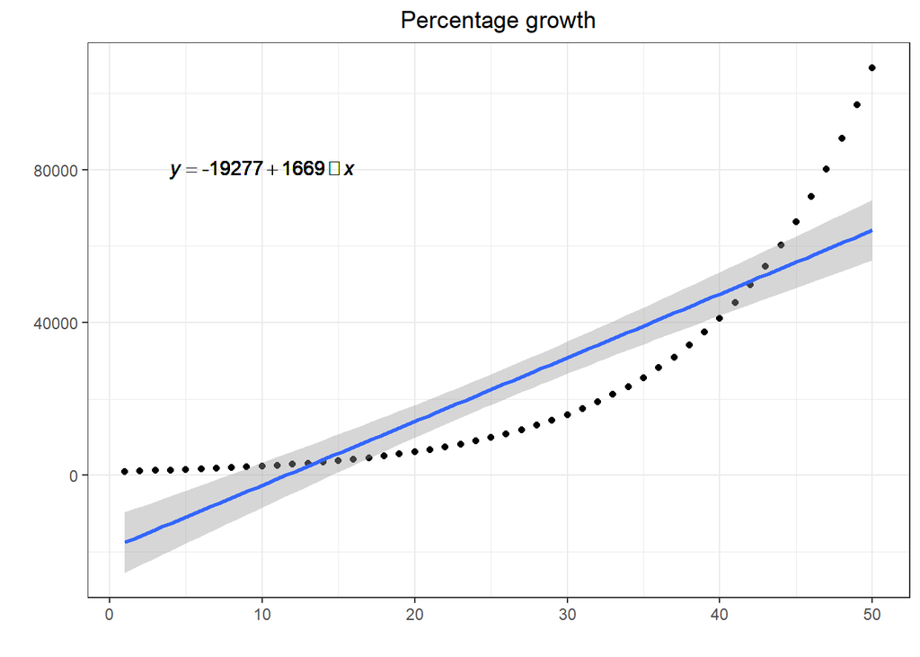

**¿Donde están los errores en este análisis?**

1. Estamos considerando valores de manera lineal
2. Estamos considerando $\beta = tg(\alpha)$ donde $\alpha$ representa un ángulo
3. Los ejes no pertenecen al mismo conjunto (o mas correctamente espacio vectorial)

Vayamos por partes:

### Valores o variaciones

Supongamos, siguiendo con nuestros ejemplos, que tenemos dos opciones:

1. Invierto 1.000 um. y al día siguiente recupero 1.050 um
2. Invierto 100 um. y al día siguiente recupero 110 um

Evidentemente, el primer caso es mejor, puesto que un día gano 50 um. frente a 10 de la opción 2 (no estamos considerando los riesgos ni el importe inicial). La realidad:

$$\begin{aligned}
opcion 1 &= (\frac{1050}{1000} - 1) * \frac{1}{100} &= 5\% \\
opcion 2 &= (\frac{110}{100} - 1) * \frac{1}{100} &= 10\%
\end{aligned}$$
Con lo que la opción 2 es el **doble de rentable** que la opción 1.

**Para evaluar la evolución de una cotización usamos **siempre** la variación, no los valores**

Ajustemos los datos de los ejemplos según estos criterios:

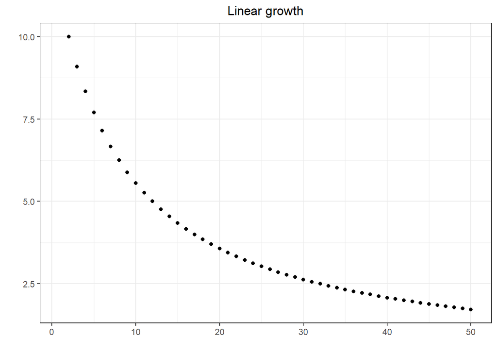

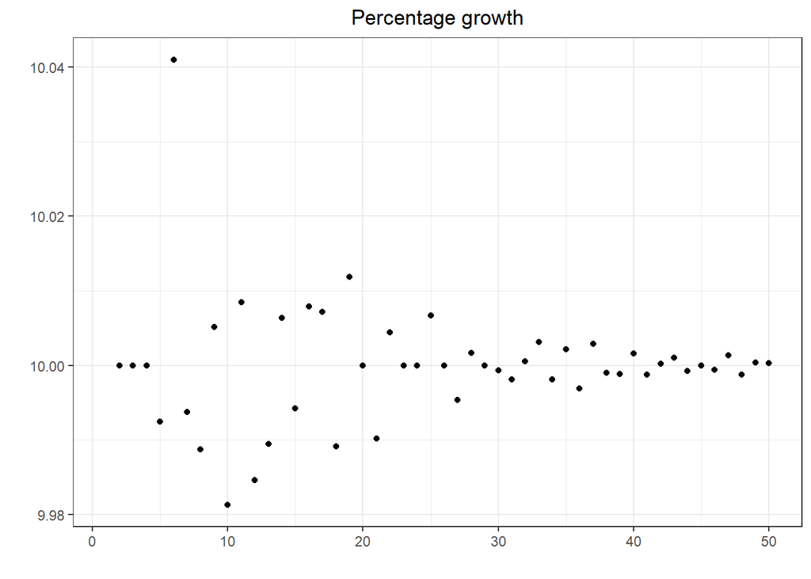

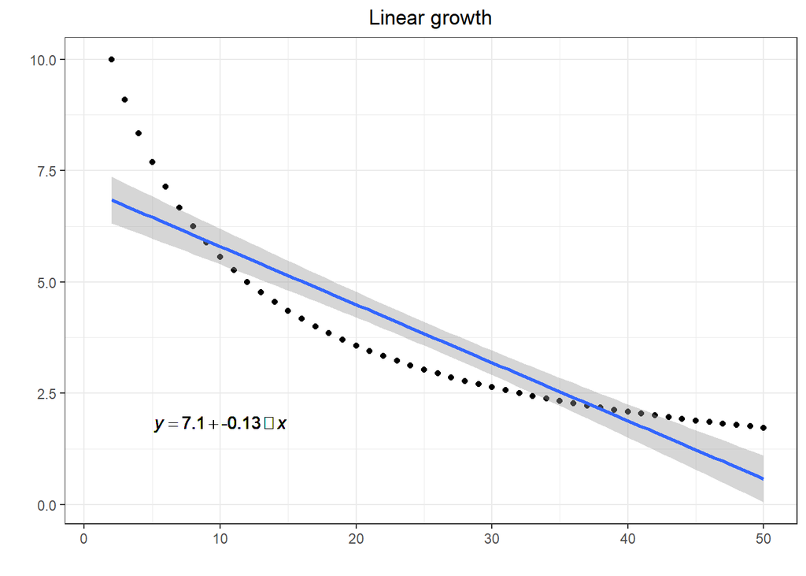

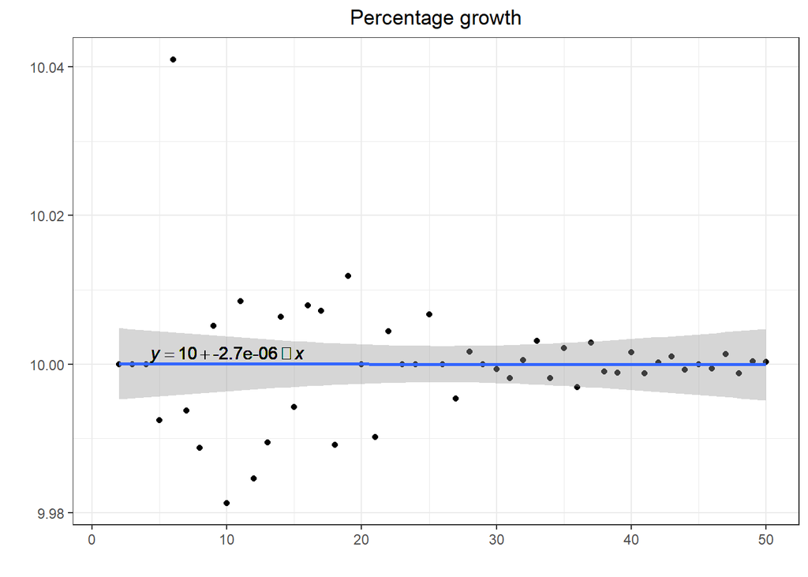

Aqui ya tenemos algo de información util.

Si miramos el segundo gráfico, observamos que la linea de regresión es practicamente horizontal (las variaciones son debidas a los redondeos que hemos aplicado) mientras que en la primera el peso de cada día afecta negativamente.

Con esta información podemos asumir ya cierta información acerca de la evolución de la cotización; mas concretamente en el primer grupo parece que la previsión de ganacias cada vez es menor puesto que $\beta$ es negativo mientras que la segunda opción muestra una evolución mas estable $\beta$ es practicamente cero con lo que podemos asumir que la ganancia esperada en esta opción será $\alpha$

### Ejemplo

Supongamos que nos encontramos en el día 20 y abrimos una operación a 10 días. Según los datos anteriores tenemos (redondeando:

$$\begin{aligned}
y_1 &= 7.1 + -0.13 . x_1 \\
y_2 &= 10 + 0 . x_2
\end{aligned}$$